# Lasquite_linear_reg.rmd

Hannah Lasquite

2026-07-10

# A. Simple linear regression

*1. In RStudio, create an R Markdown file. Name it “Your Surname_linear_reg.rmd.”*

```r
library(terra)
library(sf)
#This file itself is step 1
```

*2. Read in the species data and remove unnecessary rows with NAs.*

```r
raw_herpdata <- read.csv("herpetozoa-033-095-s001.csv")
raw_herpdata
```

```
##                                                                            Sites
## 1                                                                       ASG_ET1#
## 2                                                                       ASG_ET4#
## 3                                                                       ESG_ET5#
## 4                                                                        CVT_ET6
## 5                                                                        OGF_ET8
## 6                                                                       OGF_ET10
## 7                                                                       OGF_ET12
## 8                                                                        OGF_MT1
## 9                                                                        OGF_MT4
## 10                                                                    OGF_ALAMT1
## 11                                                                    OGF_ALAMT2
## 12                                                                    OGF_ALAMT3
## 13                                                                    OGF_ALAMT5
## 14                                                                    CVT_ALAMT7
```

[output cut: 201 more lines]

```r
comp_herpdata <- complete.cases(raw_herpdata)
head(raw_herpdata[comp_herpdata, ])
```

```
##      Sites     Long     Lat Htypes Elev SPPTotal Babu Inph Liac Lipa Ocla Leta
## 1 ASG_ET1# 118.3962 9.37437    ASG  257        0    0    0    0    0    0    0
## 2 ASG_ET4# 118.3990 9.37250    ASG  215        0    0    0    0    0    0    0
## 3 ESG_ET5# 118.4008 9.37183    ESG  188        0    0    0    0    0    0    0
## 4  CVT_ET6 118.4056 9.36728    CVT  105        0    0    0    0    0    0    0
## 5  OGF_ET8 118.3861 9.37160    OGF  662        1    0    0    0    0    0    0
## 6 OGF_ET10 118.3840 9.37247    OGF  754        1    0    0    0    0    0    0
##   Meli Chfu Pumo Sasa Stnu Phev Phlo Pole Poma Brsp Cyre Geat Gege Gemo Hety
## 1    0    0    0    0    0    0    0    0    0    0    0    0    0    0    0
## 2    0    0    0    0    0    0    0    0    0    0    0    0    0    0    0
## 3    0    0    0    0    0    0    0    0    0    0    0    0    0    0    0
## 4    0    0    0    0    0    0    0    0    0    0    0    0    0    0    0
## 5    0    0    0    0    0    0    3    0    0    0    0    0    0    0    0
## 6    0    0    0    0    0    0    7    0    0    0    0    0    0    0    0
##   Eumu Bosc Dema Drru Apbo Trsu
## 1    0    0    0    0    0    0
## 2    0    0    0    0    0    0
## 3    0    0    0    0    0    0
## 4    0    0    0    0    0    0
## 5    0    0    0    0    0    0
## 6    0    0    0    0    0    0
```

```r
herpdata <- raw_herpdata[comp_herpdata, ]
#using this method since tidyverse and terra do NOT like each other

if (any(is.na(herpdata)) == T){print(sum(is.na(herpdata)))}
#Me and my anxious butt always needs to double check
```

*3. Read in the elevation data (ph_strm_geo.tif).*

```r
PHMap <- rast("phMap.tif")
```

*4. From the species data, subset the longitude and latitude coordinates. Then convert the coordinates to a spatial vector using the “vect” function from the “terra” package.*

```r
coord <- vect(herpdata[,2:3])
coord
```

```
## class       : SpatVector
## geometry    : points
## dimensions  : 49, 0  (geometries, attributes)
## extent      : 118.1745, 118.5169, 9.32028, 9.5706  (xmin, xmax, ymin, ymax)
## coord. ref. :
```

*5. Using the converted coordinates, extract elevation data for each point with the “extract” function in the “terra” package. The extracted data will have two columns: “ID” and “Band_1.” The “Band_1” column contains the elevation.*

```r
comp_coord <- extract(PHMap, coord)
```

*6. Subset the species data to retain only the species richness column (SPPTotal). Then combine this column with the extracted elevation. Rename “Band_1” to “elevation.”*

```r
specrich <- herpdata[, 6]
comb_coord_specrich <- data.frame(
  Species_Richness = specrich,
  Elevation = comp_coord[,2])
```

*7. Now, perform simple linear regression using the code from the pre-lab lecture, including a plot. What can you infer about the relationship between species and elevation?*

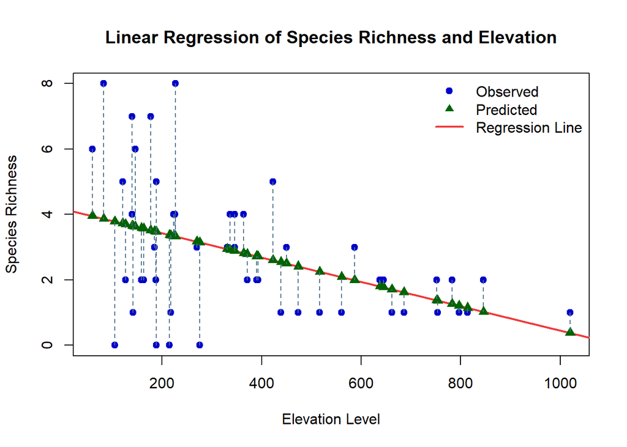

```r
x <- comb_coord_specrich$Elevation
y <- comb_coord_specrich$Species_Richness

xbar <- mean(x)
ybar <- mean(y)

b <- sum((x - xbar) * (y - ybar)) / sum((x - xbar)^2)
a <- ybar - b * xbar
yhat <- a + b * x

singplot_dat <- data.frame(
  Species_Richness = x,
  Elevation = y,
  Predicted = round(yhat,2)
)

plot(x, y,
     pch = 19,
     col = "blue3",
     xlab = "Elevation Level",
     ylab = "Species Richness",
     main = "Linear Regression of Species Richness and Elevation")
abline(a, b,
       col = "brown2",
       lwd = 2)
points(x, yhat,
       pch = 17,      # Triangle
       col = "darkgreen",
       cex = 1.2)
segments(x0 = x, y0 = y,
         x1 = x, y1 = yhat,
         lty = 2,
         col = "skyblue4")
legend("topright",
       legend = c("Observed", "Predicted", "Regression Line"),
       pch = c(19, 17, NA),
       lty = c(NA, NA, 1),
       col = c("blue3", "darkgreen", "brown2"),
       lwd = c(NA, NA, 2),
       bty = "n")
```

```r
SSE <- sum((y - yhat)^2)
SST <- sum((y - ybar)^2)
R2 <- 1 - (SSE / SST)
R2
```

```
## [1] 0.1916095
```

*Species Richness and Elevation Level seems to have an inverse relationship wherein species richness decreases as elevation level increases. However based on the r^2 value, only 19% of the variation in the data can be accounted for using our current model.*

# B. Multiple linear regression

*1.Read in both annual precipitation and temperature data and extract the data following the instructions from A4–5.*

```r
AnnualTemp <- rast("annual_temperature.tif")
AnnualPrecip <- rast("annual_precipitation.tif")

compTemp <- extract(AnnualTemp, coord)
compPrecip <- extract(AnnualPrecip, coord)
```

*2. Combine the extracted data with the species and elevation data into a single dataframe.*

```r
temp_precip <- data.frame(
  Temperature = compTemp[,2],
  Precipitation = compPrecip[,2]
)

MultLin_data <- cbind(comb_coord_specrich, temp_precip)
MultLin_data
```

```
##    Species_Richness Elevation Temperature Precipitation
## 1                 0       276    26.23333          1714
## 2                 0       215    26.23333          1714
## 3                 0       189    26.98750          1678
## 4                 0       105    26.98750          1678
## 5                 1       662    24.94583          1788
## 6                 1       754    24.94583          1788
## 7                 1       814    25.11667          1771
## 8                 1      1020    22.57500          1883
## 9                 1       474    24.18333          1780
## 10                1       439    25.43750          1684
## 11                1       517    25.43750          1684
## 12                1       561    24.69167          1734
## 13                1       686    24.42500          1754
## 14                1       797    23.60000          1803
```

[output cut: 35 more lines]

*3. Perform multiple linear regression using the “lm” function.*

```r
MultLin <- lm(MultLin_data$Species_Richness ~ MultLin_data$Elevation + MultLin_data$Temperature + MultLin_data$Precipitation)
coef(MultLin)
```

```
##                (Intercept)     MultLin_data$Elevation
##               76.724668071               -0.003624483
##   MultLin_data$Temperature MultLin_data$Precipitation
##               -1.397486338               -0.021655249
```

```r
a <- coef(MultLin)[1]
b <- coef(MultLin)[2]
c <- coef(MultLin)[3]
d <- coef(MultLin)[4]

cat("Regression Equation:\n")
```

```
## Regression Equation:
```

```r
cat("y =", round(a,3), "+", round(b,3), "x", "+", round(c,3), "x1", "+", round(d,3), "x2\n\n")
```

```
## y = 76.725 + -0.004 x + -1.397 x1 + -0.022 x2
```

```r
multyhat <- predict(MultLin)

residuals <- residuals(MultLin)

summary(MultLin)$r.squared
```

```
## [1] 0.3084179
```

```r
Multresult <- data.frame(
  Elevation = MultLin_data$Elevation,
  Precipitation = MultLin_data$Precipitation,
  Temperature = MultLin_data$Temperature,
  Observed = MultLin_data$Species_Richness,
  Predicted = round(multyhat,2),
  Residual = round(residuals,2)
)

Multresult
```

```
##    Elevation Precipitation Temperature Observed Predicted Residual
## 1        276          1714    26.23333        0      1.95    -1.95
## 2        215          1714    26.23333        0      2.17    -2.17
## 3        189          1678    26.98750        0      1.99    -1.99
## 4        105          1678    26.98750        0      2.29    -2.29
## 5        662          1788    24.94583        1      0.74     0.26
## 6        754          1788    24.94583        1      0.41     0.59
## 7        814          1771    25.11667        1      0.32     0.68
## 8       1020          1883    22.57500        1      0.70     0.30
## 9        474          1780    24.18333        1      2.66    -1.66
## 10       439          1684    25.43750        1      3.12    -2.12
## 11       517          1684    25.43750        1      2.83    -1.83
## 12       561          1734    24.69167        1      2.63    -1.63
## 13       686          1754    24.42500        1      2.12    -1.12
## 14       797          1803    23.60000        1      1.81    -0.81
```

[output cut: 35 more lines]

```r
summary(MultLin)
```

```
##
## Call:
## lm(formula = MultLin_data$Species_Richness ~ MultLin_data$Elevation +
##     MultLin_data$Temperature + MultLin_data$Precipitation)
##
## Residuals:
##     Min      1Q  Median      3Q     Max
## -2.9599 -1.1531 -0.0372  0.6773  5.8759
##
## Coefficients:
##                             Estimate Std. Error t value Pr(>|t|)
## (Intercept)                76.724668  26.354033   2.911  0.00558 **
## MultLin_data$Elevation     -0.003624   0.002970  -1.221  0.22863
## MultLin_data$Temperature   -1.397486   0.627803  -2.226  0.03107 *
## MultLin_data$Precipitation -0.021655   0.009518  -2.275  0.02770 *
## ---
## Signif. codes:  0 '***' 0.001 '**' 0.01 '*' 0.05 '.' 0.1 ' ' 1
##
## Residual standard error: 1.801 on 45 degrees of freedom
## Multiple R-squared:  0.3084, Adjusted R-squared:  0.2623
## F-statistic: 6.689 on 3 and 45 DF,  p-value: 0.0007873
```

*4. Which relationship is statistically significant?*

*Only Temperature and Precipitation have a statistically significant relationship because they have P-values less than 0.05. Elevation is not a significally different enough to be considered an important factor.*